# Biodiversity across a salinity gradient

Chloe J McGovern

# Goals

Run an analysis on the within sample biodiversity of the samples in our project.

1. First calculate the Hill numbers od the samples using the iNEXT package.
2. Plot and evaluate the interpolated and extrapolated rarefaction curves from iNEXT.
3. Analyze the hill numbers as it relates to stations and salinity in (PSU).
4. Answer the scientific question at hand.
1. `phytree_preprocessed_physeq`

## Outputs

1. Calculated biodiversity measures (Hill numbers) across every sample.
2. Figures to visualize these changes in biodiversity.
3. Statistical tests to actually show the canges and patters in biodiversity.

# Set up the environment

## Set the seed

```r
set.seed(238428)
```

## Load packages and colors

```r
pacman::p_load(tidyverse, devtools, patchwork, iNEXT, phyloseq,
               install=FALSE)

# load in colors for plotting
source("code/colors.R")
```

## Load in data

```r
load("data/04_Phylogenetic_Tree/phytree_preprocessed_physeqs.RData")

# take a look
archaeal_rooted_physeq
```

```
## phyloseq-class experiment-level object
## otu_table()   OTU Table:         [ 2605 taxa and 89 samples ]
## sample_data() Sample Data:       [ 89 samples by 43 sample variables ]
## tax_table()   Taxonomy Table:    [ 2605 taxa by 9 taxonomic ranks ]
## phy_tree()    Phylogenetic Tree: [ 2605 tips and 2604 internal nodes ]
```

```r
# intuition check on seq depth
min(sample_sums(archaeal_rooted_physeq)) #max, min, medium
```

```
## [1] 1576
```

```r
# make metadata df
metadata_df<- archaeal_rooted_physeq %>%
  sample_data() %>%
  data.frame()

glimpse(metadata_df)
```

```
## Rows: 89
## Columns: 43
## $ year                <chr> "2021", "2021", "2021", "2021", "2021", "2021", "2…
## $ day                 <chr> "02", "02", "02", "02", "02", "02", "02", "02", "0…
## $ project             <chr> "MA", "MA", "MA", "MA", "MA", "MA", "MA", "MA", "M…
## $ station             <chr> "Aransas Bay", "Aransas Bay", "Aransas Bay", "Aran…
## $ depth               <dbl> 2.5, 2.5, 2.5, 0.0, 0.0, 0.0, 2.0, 2.0, 2.0, 0.0, …
## $ replicate           <dbl> 1, 1, 1, 1, 1, 1, 1, 1, 1, 1, 1, 1, 1, 1, 1, 1, 1,…
## $ fraction            <chr> "Free", "Particle", "Whole", "Free", "Particle", "…
## $ date                <chr> "6/2/21", "6/2/21", "6/2/21", "6/2/21", "6/2/21", …
## $ month               <chr> "June", "June", "June", "June", "June", "June", "J…
## $ vol_filtered_mL     <dbl> 360, 360, 360, 300, 300, 300, 183, 183, 285, 146, …
## $ DNA_conc1a_nguL     <dbl> 25.90, 2.91, 65.30, 39.70, 10.40, 47.40, 32.50, 1.…
## $ total_uL_DNA        <dbl> 44.61, 34.00, 43.36, 44.94, 42.54, 45.11, 44.89, 3…
## $ tot_ng              <dbl> 1207, 105, 2962, 1864, 463, 2233, 1524, 51, 3164, …
```

[output cut: 30 more lines]

# Calculate biodiversity with iNEXT

```r
# prepare the input data
  #species in rows, samples in columns

iNEXT_input_df <-
  archaeal_rooted_physeq %>%
  otu_table() %>%
  data.frame()

# inspect
dim(iNEXT_input_df)
```

```
## [1] 2605   89
```

```r
iNEXT_input_df[1:5,1:5]
```

```
##          X20210602.MA.ABB1F X20210602.MA.ABB1P X20210602.MA.ABB1W
## ASV_1971                  3                  0                  0
## ASV_2876                  0                  0                  0
## ASV_2326                  0                  2                  0
## ASV_2157                  0                  0                  0
## ASV_2378                  0                  0                  0
##          X20210602.MA.ABS1F X20210602.MA.ABS1P
## ASV_1971                  0                  0
## ASV_2876                  0                  0
## ASV_2326                  0                  0
## ASV_2157                  0                  0
## ASV_2378                  0                  0
```

```r
# run iNEXT
  # remember to set the seed
  #ASVs in rows, samples in columns

#iNEXT_data <- iNEXT(iNEXT_input_df,
#                    q = c(0,1,2),
#                    datatype = "abundance") #takes a while to run
```

Since iNEXT takes a while ti run, we will load in the data that was calculated before

```r
load("data/05_Biodiversity/iNEXT_data.RData")

# inspect
str(iNEXT_data)
```

```
## List of 3
##  $ DataInfo:'data.frame':    89 obs. of  14 variables:
##   ..$ Assemblage: chr [1:89] "X20210602.MA.ABB1F" "X20210602.MA.ABB1P" "X20210602.MA.ABB1W" "X20210602.MA.ABS1F" ...
##   ..$ n         : num [1:89] 3430 2603 4784 3182 3190 ...
##   ..$ S.obs     : num [1:89] 137 118 140 120 133 127 133 119 141 126 ...
##   ..$ SC        : num [1:89] 1 1 1 1 1 1 1 1 1 1 ...
##   ..$ f1        : num [1:89] 0 0 0 0 0 0 0 0 0 0 ...
##   ..$ f2        : num [1:89] 4 18 11 11 11 8 7 11 9 10 ...
##   ..$ f3        : num [1:89] 12 9 9 6 11 5 5 5 9 3 ...
##   ..$ f4        : num [1:89] 7 8 9 4 8 7 5 8 5 5 ...
##   ..$ f5        : num [1:89] 8 4 7 10 3 9 6 6 6 8 ...
##   ..$ f6        : num [1:89] 8 8 4 9 6 2 7 4 6 3 ...
##   ..$ f7        : num [1:89] 2 5 6 5 10 5 3 5 6 7 ...
##   ..$ f8        : num [1:89] 3 3 3 4 6 7 2 3 5 7 ...
##   ..$ f9        : num [1:89] 8 2 5 2 6 4 6 5 3 3 ...
##   ..$ f10       : num [1:89] 6 5 7 4 1 5 6 5 10 5 ...
##  $ iNextEst:List of 2
##   ..$ size_based    :'data.frame':   10680 obs. of  10 variables:
##   .. ..$ Assemblage: chr [1:10680] "X20210602.MA.ABB1F" "X20210602.MA.ABB1F" "X20210602.MA.ABB1F" "X20210602.MA.ABB1F" ...
##   .. ..$ m         : num [1:10680] 1 191 381 572 762 ...
##   .. ..$ Method    : chr [1:10680] "Rarefaction" "Rarefaction" "Rarefaction" "Rarefaction" ...
##   .. ..$ Order.q   : num [1:10680] 0 0 0 0 0 0 0 0 0 0 ...
##   .. ..$ qD        : num [1:10680] 1 72.3 97.8 111.1 119 ...
##   .. ..$ qD.LCL    : num [1:10680] 1 71.1 96.3 109.3 117 ...
##   .. ..$ qD.UCL    : num [1:10680] 1 73.5 99.3 112.9 121 ...
##   .. ..$ SC        : num [1:10680] 0.0454 0.8063 0.9081 0.9477 0.9669 ...
##   .. ..$ SC.LCL    : num [1:10680] 0.0414 0.8021 0.9045 0.945 0.965 ...
##   .. ..$ SC.UCL    : num [1:10680] 0.0495 0.8105 0.9117 0.9505 0.9688 ...
##   ..$ coverage_based:'data.frame':   5073 obs. of  8 variables:
##   .. ..$ Assemblage: chr [1:5073] "X20210602.MA.ABB1F" "X20210602.MA.ABB1F" "X20210602.MA.ABB1F" "X20210602.MA.ABB1F" ...
##   .. ..$ SC        : num [1:5073] 0.0454 0.8063 0.9081 0.9477 0.9669 ...
##   .. ..$ m         : num [1:5073] 1 191 381 572 762 ...
##   .. ..$ Method    : chr [1:5073] "Rarefaction" "Rarefaction" "Rarefaction" "Rarefaction" ...
##   .. ..$ Order.q   : num [1:5073] 0 0 0 0 0 0 0 0 0 0 ...
##   .. ..$ qD        : num [1:5073] 1 72.3 97.8 111.1 119 ...
##   .. ..$ qD.LCL    : num [1:5073] 0.962 70.492 95.652 108.635 116.414 ...
##   .. ..$ qD.UCL    : num [1:5073] 1.04 74.18 99.94 113.54 121.62 ...
##  $ AsyEst  :'data.frame':    267 obs. of  7 variables:
##   ..$ Assemblage: chr [1:267] "X20210602.MA.ABB1F" "X20210602.MA.ABB1F" "X20210602.MA.ABB1F" "X20210602.MA.ABB1P" ...
##   ..$ Diversity : chr [1:267] "Species richness" "Shannon diversity" "Simpson diversity" "Species richness" ...
##   ..$ Observed  : num [1:267] 137 57.9 21.9 118 49.4 ...
##   ..$ Estimator : num [1:267] 137 59 22 118 50.5 ...
##   ..$ s.e.      : num [1:267] 2.02 1.53 1.03 3.5 1.14 ...
##   ..$ LCL       : num [1:267] 137 56 20 118 48.3 ...
##   ..$ UCL       : num [1:267] 141 62 24 124.9 52.7 ...
##  - attr(*, "class")= chr "iNEXT"
```

```r
typeof(iNEXT_data)
```

```
## [1] "list"
```

# Plot the rarefaction curves

```r
# Prepare Colors
color_df <-
  iNEXT_input_df %>%
  colnames() %>%
  data.frame()
# Check
head(color_df)
```

```
##                    .
## 1 X20210602.MA.ABB1F
## 2 X20210602.MA.ABB1P
## 3 X20210602.MA.ABB1W
## 4 X20210602.MA.ABS1F
## 5 X20210602.MA.ABS1P
## 6 X20210602.MA.ABS1W
```

```r
# Rename the column
colnames(color_df)[1] <- "names"
# Check
head(color_df)
```

```
##                names
## 1 X20210602.MA.ABB1F
## 2 X20210602.MA.ABB1P
## 3 X20210602.MA.ABB1W
## 4 X20210602.MA.ABS1F
## 5 X20210602.MA.ABS1P
## 6 X20210602.MA.ABS1W
```

```r
# Make a helper dataframe for plotting with colors
iNEXT_color_df <-
  color_df %>%
  # Fix the names for merging
  mutate(names = gsub(names, pattern = "[.]", replace = "-"),
         names = gsub(names, pattern = "X",  replace = "")) %>%
  # Merge with metadata
  left_join(metadata_df, by = "names") %>%
  # Merge with colors for plotting with ggiNEXT
  left_join(data.frame(station_colors = station_colors,
            station = names(station_colors)),
            by = "station")

head(iNEXT_color_df)
```

```
##               names year day project     station depth replicate fraction
## 1 20210602-MA-ABB1F 2021  02      MA Aransas Bay   2.5         1     Free
## 2 20210602-MA-ABB1P 2021  02      MA Aransas Bay   2.5         1 Particle
## 3 20210602-MA-ABB1W 2021  02      MA Aransas Bay   2.5         1    Whole
## 4 20210602-MA-ABS1F 2021  02      MA Aransas Bay   0.0         1     Free
## 5 20210602-MA-ABS1P 2021  02      MA Aransas Bay   0.0         1 Particle
## 6 20210602-MA-ABS1W 2021  02      MA Aransas Bay   0.0         1    Whole
##     date month vol_filtered_mL DNA_conc1a_nguL total_uL_DNA tot_ng
## 1 6/2/21  June             360           25.90        44.61   1207
## 2 6/2/21  June             360            2.91        34.00    105
## 3 6/2/21  June             360           65.30        43.36   2962
## 4 6/2/21  June             300           39.70        44.94   1864
## 5 6/2/21  June             300           10.40        42.54    463
## 6 6/2/21  June             300           47.40        45.11   2233
##   tot_filtration_time collection_time process_time sitting_time julian_day
```

[output cut: 34 more lines]

Remember the output of iNEXT

q = 0 richness q = 1 shannon q = 2 simpson

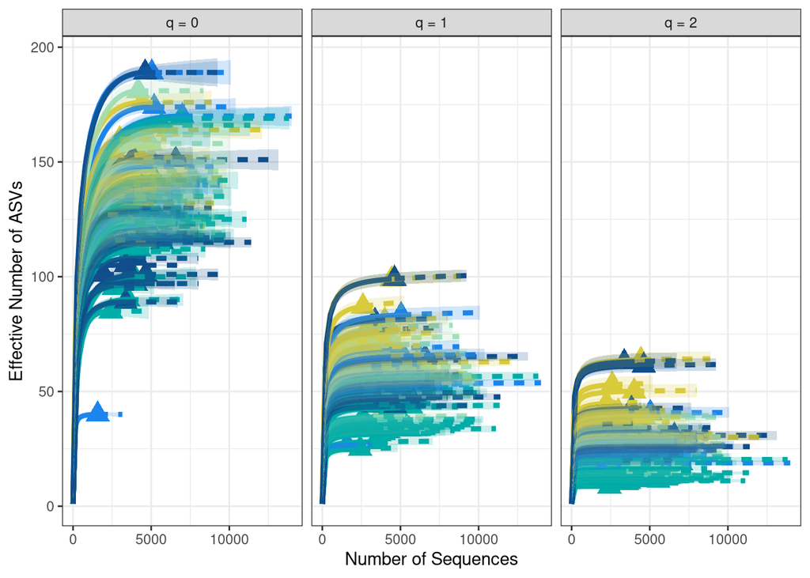

```r
ggiNEXT(iNEXT_data, type = 1, facet.var = "Order.q") +
  scale_color_manual(values = iNEXT_color_df$station_colors) +
  scale_fill_manual(values = iNEXT_color_df$station_colors) +
  scale_shape_manual(values = base::rep(17, nsamples(archaeal_rooted_physeq)),
                     guide = FALSE) +
  theme_bw() +
  theme(legend.position = "none") +
  labs(y = "Effective Number of ASVs", x = "Number of Sequences")
```

As we increase the q value, we are increasing the weight of the proportion. Dominant species are bring weighted more as `q` goes up

Inverse Simpson least sensitive to sequencing depth. But if we care about rare groups, richness and rarefaction curves

Finally, let’s draw some conclusions from the plot above (we discussed in class & I’ll summarize here):

As q increases from 0 to 1 to 2, the abundance of the species is weighted more, so the rarefaction curve plateaus earlier.

This is important because it indicates that richess is the most sensitive to sequencing depth!

However, Shannon and even less sensitive is Simpson!

Most of the sample rarefaction curves appear to plateau but we need to look deeper.

There appears to be a sample with much lower richness than the rest of the dataset. Let’s keep our eyes on this sample.

# Manually plot the rarefaction

```r
str(iNEXT_data)
```

```
## List of 3
##  $ DataInfo:'data.frame':    89 obs. of  14 variables:
##   ..$ Assemblage: chr [1:89] "X20210602.MA.ABB1F" "X20210602.MA.ABB1P" "X20210602.MA.ABB1W" "X20210602.MA.ABS1F" ...
##   ..$ n         : num [1:89] 3430 2603 4784 3182 3190 ...
##   ..$ S.obs     : num [1:89] 137 118 140 120 133 127 133 119 141 126 ...
##   ..$ SC        : num [1:89] 1 1 1 1 1 1 1 1 1 1 ...
##   ..$ f1        : num [1:89] 0 0 0 0 0 0 0 0 0 0 ...
##   ..$ f2        : num [1:89] 4 18 11 11 11 8 7 11 9 10 ...
##   ..$ f3        : num [1:89] 12 9 9 6 11 5 5 5 9 3 ...
##   ..$ f4        : num [1:89] 7 8 9 4 8 7 5 8 5 5 ...
##   ..$ f5        : num [1:89] 8 4 7 10 3 9 6 6 6 8 ...
##   ..$ f6        : num [1:89] 8 8 4 9 6 2 7 4 6 3 ...
##   ..$ f7        : num [1:89] 2 5 6 5 10 5 3 5 6 7 ...
##   ..$ f8        : num [1:89] 3 3 3 4 6 7 2 3 5 7 ...
##   ..$ f9        : num [1:89] 8 2 5 2 6 4 6 5 3 3 ...
##   ..$ f10       : num [1:89] 6 5 7 4 1 5 6 5 10 5 ...
##  $ iNextEst:List of 2
##   ..$ size_based    :'data.frame':   10680 obs. of  10 variables:
##   .. ..$ Assemblage: chr [1:10680] "X20210602.MA.ABB1F" "X20210602.MA.ABB1F" "X20210602.MA.ABB1F" "X20210602.MA.ABB1F" ...
##   .. ..$ m         : num [1:10680] 1 191 381 572 762 ...
##   .. ..$ Method    : chr [1:10680] "Rarefaction" "Rarefaction" "Rarefaction" "Rarefaction" ...
##   .. ..$ Order.q   : num [1:10680] 0 0 0 0 0 0 0 0 0 0 ...
##   .. ..$ qD        : num [1:10680] 1 72.3 97.8 111.1 119 ...
##   .. ..$ qD.LCL    : num [1:10680] 1 71.1 96.3 109.3 117 ...
##   .. ..$ qD.UCL    : num [1:10680] 1 73.5 99.3 112.9 121 ...
##   .. ..$ SC        : num [1:10680] 0.0454 0.8063 0.9081 0.9477 0.9669 ...
##   .. ..$ SC.LCL    : num [1:10680] 0.0414 0.8021 0.9045 0.945 0.965 ...
##   .. ..$ SC.UCL    : num [1:10680] 0.0495 0.8105 0.9117 0.9505 0.9688 ...
##   ..$ coverage_based:'data.frame':   5073 obs. of  8 variables:
##   .. ..$ Assemblage: chr [1:5073] "X20210602.MA.ABB1F" "X20210602.MA.ABB1F" "X20210602.MA.ABB1F" "X20210602.MA.ABB1F" ...
##   .. ..$ SC        : num [1:5073] 0.0454 0.8063 0.9081 0.9477 0.9669 ...
##   .. ..$ m         : num [1:5073] 1 191 381 572 762 ...
##   .. ..$ Method    : chr [1:5073] "Rarefaction" "Rarefaction" "Rarefaction" "Rarefaction" ...
##   .. ..$ Order.q   : num [1:5073] 0 0 0 0 0 0 0 0 0 0 ...
##   .. ..$ qD        : num [1:5073] 1 72.3 97.8 111.1 119 ...
##   .. ..$ qD.LCL    : num [1:5073] 0.962 70.492 95.652 108.635 116.414 ...
##   .. ..$ qD.UCL    : num [1:5073] 1.04 74.18 99.94 113.54 121.62 ...
##  $ AsyEst  :'data.frame':    267 obs. of  7 variables:
##   ..$ Assemblage: chr [1:267] "X20210602.MA.ABB1F" "X20210602.MA.ABB1F" "X20210602.MA.ABB1F" "X20210602.MA.ABB1P" ...
##   ..$ Diversity : chr [1:267] "Species richness" "Shannon diversity" "Simpson diversity" "Species richness" ...
##   ..$ Observed  : num [1:267] 137 57.9 21.9 118 49.4 ...
##   ..$ Estimator : num [1:267] 137 59 22 118 50.5 ...
##   ..$ s.e.      : num [1:267] 2.02 1.53 1.03 3.5 1.14 ...
##   ..$ LCL       : num [1:267] 137 56 20 118 48.3 ...
##   ..$ UCL       : num [1:267] 141 62 24 124.9 52.7 ...
##  - attr(*, "class")= chr "iNEXT"
```

```r
iNEXT_manual_df <-
  iNEXT_data$iNextEst$size_based %>%
  dplyr::rename(names = Assemblage) %>%
  # Fix the samples names
  mutate(names = gsub(names, pattern = "[.]", replace = "-"),
         names = gsub(names, pattern = "X", replace = "")) %>%
  # join with metadata
  left_join(., metadata_df, by = "names") %>%
  # Add colors to data frame
  left_join(., data.frame(station_colors = station_colors,
                          station = names(station_colors)),
            by = "station") %>%
  mutate(station = factor(station, levels = c("Copano West", "Copano East",
                                              "Mesquite Bay", "Aransas Bay",
                                              "Shipping Channel")))

# inspect
dim(iNEXT_manual_df)
```

```
## [1] 10680    53
```

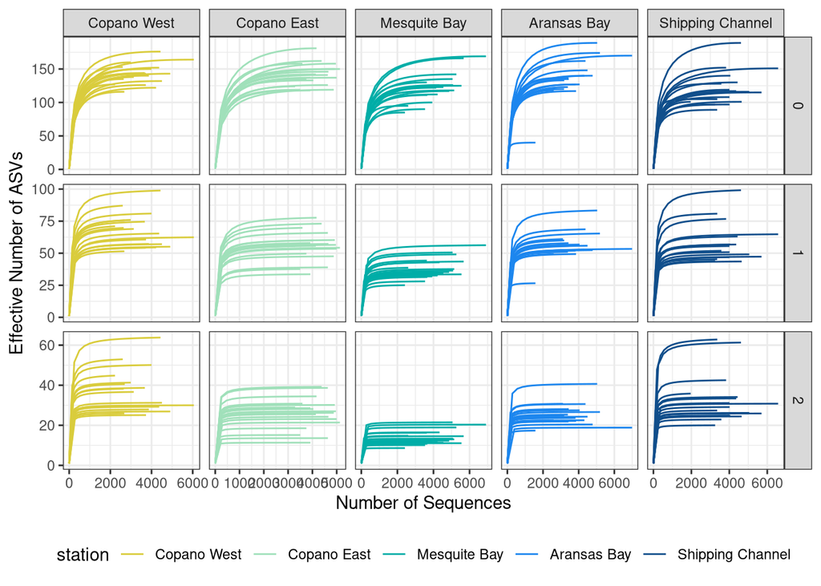

```r
# manually plot rarefaction
iNEXT_manual_df %>%
  #filter out rows that are calculated out by sequences so no extrapolated data
  dplyr::filter(Method == "Rarefaction") %>%
  # make plot!
  ggplot(aes(x = m, y = qD, color = station, group = names)) +
  geom_line() +
  #facet by station
  facet_grid(Order.q~station, scales = "free") +
  scale_color_manual(values = station_colors) +
  theme_bw() +
  labs(y = "Effective Number of ASVs", x = "Number of Sequences")+
  theme(legend.position = "bottom")
```

# Boxplot: Diversity by Station

## Categorical analysis

```r
obs_div_df <-
  iNEXT_manual_df %>%
  dplyr:: filter(Method == "Observed")

# check it out
glimpse(obs_div_df)
```

```
## Rows: 267
## Columns: 53
## $ names               <chr> "20210602-MA-ABB1F", "20210602-MA-ABB1F", "2021060…
## $ m                   <dbl> 3430, 3430, 3430, 2603, 2603, 2603, 4784, 4784, 47…
## $ Method              <chr> "Observed", "Observed", "Observed", "Observed", "O…
## $ Order.q             <dbl> 0, 1, 2, 0, 1, 2, 0, 1, 2, 0, 1, 2, 0, 1, 2, 0, 1,…
## $ qD                  <dbl> 137.00000, 57.85038, 21.87891, 118.00000, 49.36022…
## $ qD.LCL              <dbl> 134.52209, 55.38666, 20.03965, 115.32931, 47.21466…
## $ qD.UCL              <dbl> 139.47791, 60.31409, 23.71816, 120.67069, 51.50577…
## $ SC                  <dbl> 1, 1, 1, 1, 1, 1, 1, 1, 1, 1, 1, 1, 1, 1, 1, 1, 1,…
## $ SC.LCL              <dbl> 0.9988928, 0.9988928, 0.9988928, 0.9980896, 0.9980…
## $ SC.UCL              <dbl> 1, 1, 1, 1, 1, 1, 1, 1, 1, 1, 1, 1, 1, 1, 1, 1, 1,…
## $ year                <chr> "2021", "2021", "2021", "2021", "2021", "2021", "2…
## $ day                 <chr> "02", "02", "02", "02", "02", "02", "02", "02", "0…
## $ project             <chr> "MA", "MA", "MA", "MA", "MA", "MA", "MA", "MA", "M…
```

[output cut: 40 more lines]

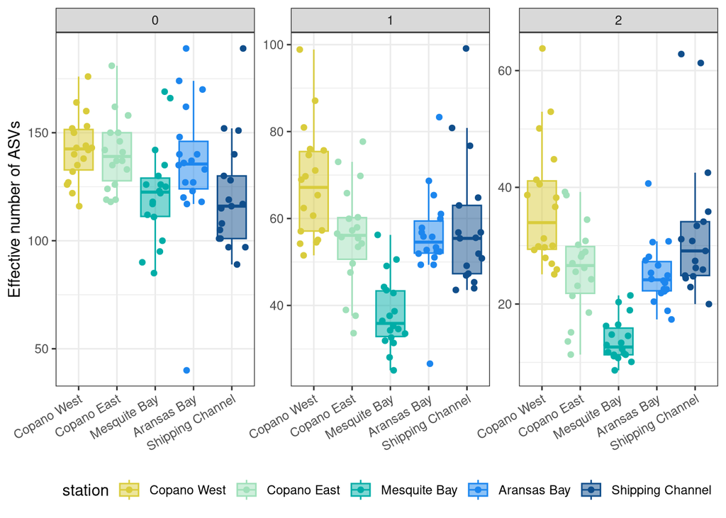

```r
# plot box plots by station against diversity

obs_div_df %>%
  ggplot(aes (x = station, y = qD, fill = station, color = station)) +
  facet_wrap(.~Order.q, scales = "free_y") +
  geom_jitter() +
  geom_boxplot(alpha = 0.5, outlier.shape = NA) +
  scale_color_manual(values = station_colors) +
  scale_fill_manual(values = station_colors) +
  labs(y = "Effective number of ASVs") +
  theme_bw() +
  theme(legend.position = "bottom",
        axis.title.x = element_blank(),
        axis.text.x = element_text(angle = 30,
                                   hjust = 1,
                                   vjust =1))
```

# Continuous Relationships - Salinity (PSU) vs Biodiversity

## Environmental Variables

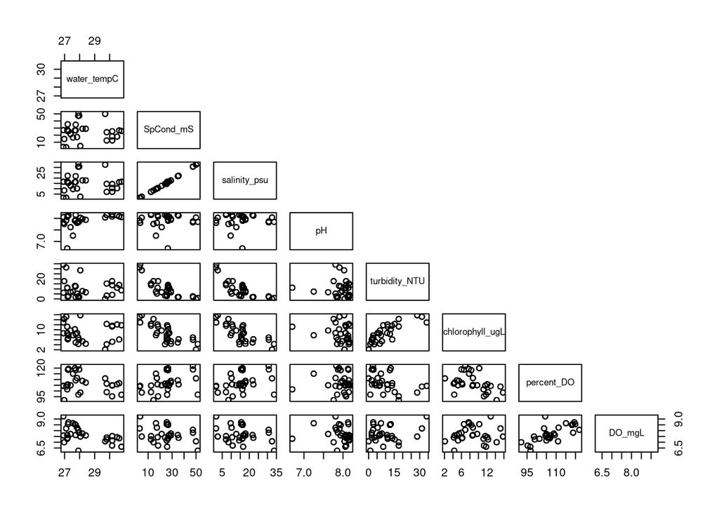

```r
# create df of env variables
env_df <-
  metadata_df %>%
  dplyr::select(names, water_tempC:DO_mgL)

# pairwise interactions between env var
pairs(dplyr::select(env_df, -names), upper.panel = NULL)
```

## PSU

- practical salinity unit
- 1 PSU = 1 g salt per 1,000 g water = ppt

0 -> 30 (gradient)

fresh: 0 - 0.5 brackish: 0.5 - 30 saline: > 30

How does biodiversity change over the salinity gradient?

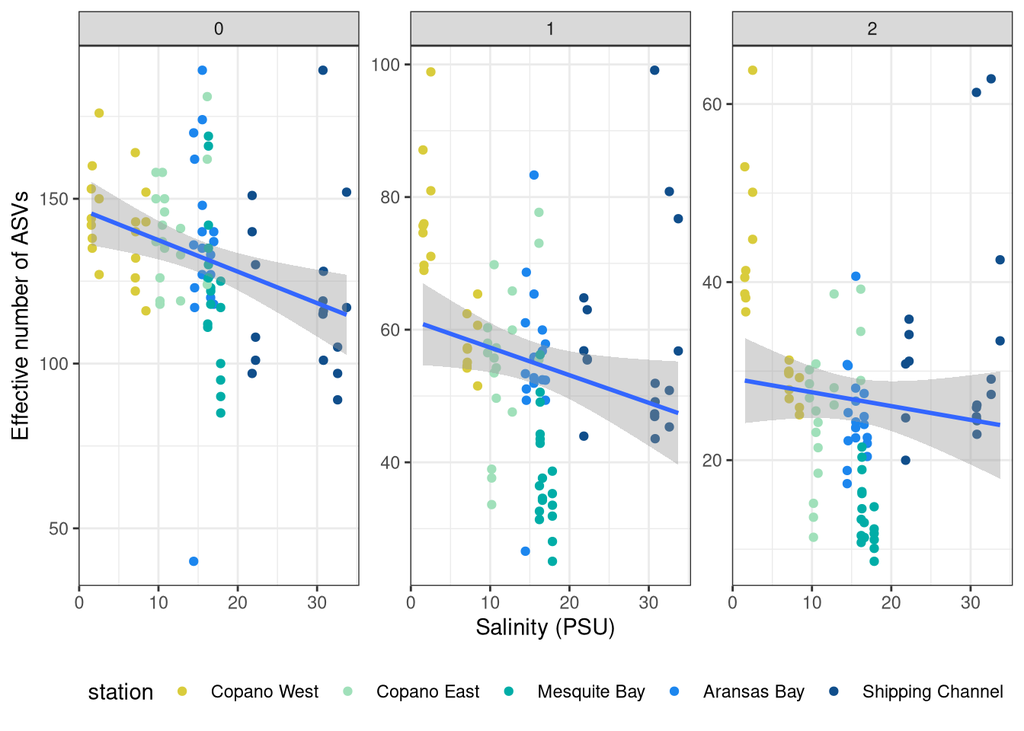

```r
obs_div_df %>%
  ggplot(aes(x = salinity_psu, y = qD)) +
  facet_wrap(.~Order.q, scales = "free") +
  geom_point(aes(color = station))+
  scale_color_manual(values = station_colors) +
  labs(x = "Salinity (PSU)", y = "Effective number of ASVs") +
  stat_smooth(method = "lm") +
  theme_bw() +
  theme(legend.position = "bottom")
```